# IE6400 Foundations of Data Analytics Engineering

# Fall 2023

### Module 3: Linear Algebra Part-2

### Matrices

"Matrices" (singular: matrix) refer to rectangular arrays of numbers, symbols, or expressions, arranged in rows and columns. They are a fundamental concept in linear algebra and have various applications in pure mathematics, physics, computer science, economics, and other fields.

For example, consider the matrix A:

> $ A = \begin{bmatrix} a & b \\ c & d \\ \end{bmatrix} $

This matrix has 2 rows and 2 columns, making it a 2x2 matrix. The entry in the first row and first column is (a), the entry in the first row and second column is (b), and so on.

#### Types of Matrices

There are several types of matrices, including:

- **Row matrix**: Only one row.
- **Column matrix**: Only one column.
- **Square matrix**: Same number of rows and columns.
- **Diagonal matrix**: All non-diagonal elements are zero.
- **Identity matrix**: A square matrix where diagonal elements are 1 and non-diagonal elements are 0.
- **Zero matrix**: All elements are zero.
- **Symmetric matrix**: It remains unchanged upon taking its transpose.
- **Skew-symmetric matrix**: Its negative is its transpose.
- **Orthogonal matrix**: Its transpose is its inverse.

#### Matrix Operations

Several operations can be performed with matrices, including:

- **Addition**: You can add two matrices of the same dimension by adding corresponding elements.
- **Scalar Multiplication**: Multiply each element of the matrix by a scalar (a single number).
- **Matrix Multiplication**: Multiplying two matrices involves taking the dot product of rows of the first matrix with columns of the second.
- **Transpose**: Reflect the matrix over its main diagonal.
- **Determinant**: A scalar value derived from a square matrix.
- **Inverse**: If it exists, the inverse of a matrix is such that when it's multiplied with the original matrix, the result is the identity matrix.

#### Applications of Matrices

Matrices are used in various fields and applications, including:

- **Linear Transformations**: Representing transformations in geometry.
- **Solving Systems of Linear Equations**: Using techniques like Gauss-Jordan elimination or Cramer's rule.
- **Computer Graphics**: For transformations like rotation, scaling, and translation.
- **Quantum Mechanics**: Representing quantum states and operations.
- **Economics**: Input-output analysis.
- **Data Analysis**: In areas such as Principal Component Analysis (PCA).

Understanding the properties and operations of matrices is foundational in linear algebra, and linear algebra itself is crucial for many advanced topics in mathematics and its applications.

### Types of Matrices

A lot of linear algebra is concerned with operations on vectors and matrices, and there are many different types of matrices. There are a few types of matrices that you may encounter again and again when getting started in linear algebra, particularity the parts of linear algebra relevant to machine learning.

#### Square Matrix

A square matrix is a matrix where the number of rows $(n)$ is equivalent to the number of columns $(m)$.

> $n=m$

The size of the matrix is called the order, so an order 4 square matrix is 4 × 4.

#### Symmetric Matrix

A symmetric matrix is a type of square matrix where the top-right triangle is the same as the bottom-left triangle.

To be symmetric, the axis of symmetry is always the main diagonal of the matrix, from the top left to the bottom right.

A symmetric matrix is always square and equal to its own transpose. The transpose is an operation that flips the number of rows and columns. It is explained in more detail in the next lesson.

> $M = M^T$

#### Exercise 1 Understanding Square Matrices using Python

#### Problem Statement

You are a data scientist working for a robotics company. The company uses transformation matrices to represent the orientation and position of robots in 3D space. These matrices are often square matrices. Your task is to generate a square matrix and visualize its properties.

**Objective:** Generate a square matrix and visualize its structure. Identify if the matrix is symmetric.

#### Step 1: Importing Necessary Libraries

```python
#!pip install matplotlib==3.7.3
```

```python
import numpy as np
import matplotlib.pyplot as plt
import seaborn as sns
```

#### Step 2: Generating the Dataset

For this exercise, we'll create a 4x4 square matrix with random values.

```python
# Generating a random 4x4 square matrix
np.random.seed(0)
square_matrix = np.random.randint(1, 10, size=(4, 4))
```

#### Step 3: Visualizing the Square Matrix

We'll use a heatmap to visualize the structure of the square matrix.

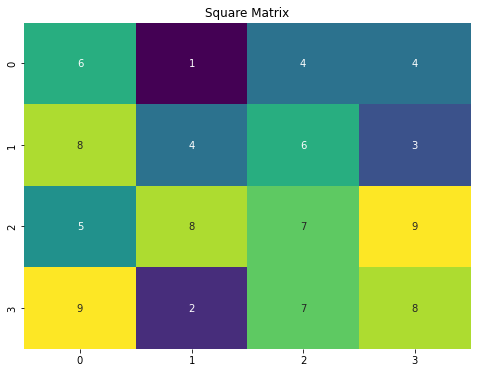

```python
# Plotting the square matrix as a heatmap
plt.figure(figsize=(8, 6))
sns.heatmap(square_matrix, annot=True, cmap='viridis', cbar=False)
plt.title('Square Matrix')
plt.show()
```

#### Step 4: Checking for Symmetry

A square matrix is symmetric if it is equal to its transpose. We'll check if our matrix is symmetric.

```python
# Checking if the matrix is symmetric
is_symmetric = np.array_equal(square_matrix, square_matrix.T)
```

#### Step 5: Interpretation

From the visualization, we can see the structure of our 4x4 square matrix. Each cell represents a value in the matrix.

Regarding symmetry:

```python
if is_symmetric:
    print("The matrix is symmetric.")
else:
    print("The matrix is not symmetric.")
```

```
The matrix is not symmetric.
```

#### Conclusion

Through this exercise, we've visualized and understood the concept of a square matrix. Square matrices are matrices with the same number of rows and columns. They play a crucial role in linear algebra, especially in transformations, eigenvalues, and eigenvectors. Recognizing the properties of square matrices, such as symmetry, can be useful in various mathematical and engineering applications.

#### Triangular Matrix

A triangular matrix is a type of square matrix that has all values in the upper-right or lower-left of the matrix with the remaining elements filled with zero values. A triangular matrix with values only above the main diagonal is called an upper triangular matrix. Whereas, a triangular matrix with values only below the main diagonal is called a lower triangular matrix. Below is an example of a 3 × 3 upper triangular matrix.

> $a = \begin{bmatrix} 1 & 2 & 3 \\ 0 & 2 & 3\\ 0 & 0 & 3 \end{bmatrix}$

#### Exercise 2 Understanding Triangular Matrices using Python

#### Problem Statement

You are a data scientist working for a company that specializes in numerical algorithms. One of the foundational concepts in linear algebra that the company often uses is the triangular matrix. Your task is to generate both an upper and a lower triangular matrix and visualize their structures.

**Objective:** Generate an upper and a lower triangular matrix and visualize their structures. Understand the properties and significance of triangular matrices.

#### Step 1: Importing Necessary Libraries

```python
import numpy as np
import matplotlib.pyplot as plt
import seaborn as sns
```

#### Step 2: Generating the Dataset

For this exercise, we'll create a 5x5 matrix with random values and then derive both its upper and lower triangular matrices.

```python
# Generating a random 5x5 matrix
np.random.seed(0)
matrix_A = np.random.randint(1, 10, size=(5, 5))

# Extracting the upper and lower triangular matrices
upper_triangular = np.triu(matrix_A)
lower_triangular = np.tril(matrix_A)
```

#### Step 3: Visualizing the Matrices

We'll use heatmaps to visualize the structures of the original, upper triangular, and lower triangular matrices.

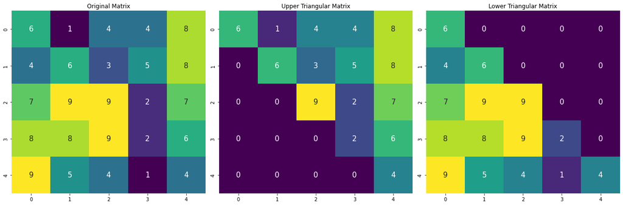

```python
# Plotting the matrices as heatmaps
fig, ax = plt.subplots(1, 3, figsize=(18, 6))

sns.heatmap(matrix_A, annot=True, cmap='viridis', cbar=False, ax=ax[0], annot_kws={"size": 15})
ax[0].set_title('Original Matrix')

sns.heatmap(upper_triangular, annot=True, cmap='viridis', cbar=False, ax=ax[1], annot_kws={"size": 15})
ax[1].set_title('Upper Triangular Matrix')

sns.heatmap(lower_triangular, annot=True, cmap='viridis', cbar=False, ax=ax[2], annot_kws={"size": 15})
ax[2].set_title('Lower Triangular Matrix')

plt.tight_layout()
plt.show()
```

#### Interpretation

From the visualizations:

- The first heatmap represents our original matrix.
- The second heatmap represents the upper triangular matrix derived from the original matrix. Notice that all values below the main diagonal are zeros.
- The third heatmap represents the lower triangular matrix derived from the original matrix. Notice that all values above the main diagonal are zeros.

Triangular matrices are significant in numerical linear algebra, especially in methods for solving linear systems of equations. Their structure ensures reduced computational complexity in certain algorithms.

#### Conclusion

Through this exercise, we've visualized and understood the concept of triangular matrices. Recognizing and working with triangular matrices can simplify many mathematical operations and are fundamental in various algorithms in linear algebra.

#### Diagonal Matrix

A diagonal matrix is one where values outside of the main diagonal have a zero value, where the main diagonal is taken from the top left of the matrix to the bottom right. A diagonal matrix is often denoted with the variable D and may be represented as a full matrix or as a vector of values on the main diagonal. Below is an example of a 3 × 3 square diagonal matrix.

> $a = \begin{bmatrix} 1 & 0 & 0 \\ 0 & 1 & 0\\ 0 & 0 & 1 \end{bmatrix}$

#### Exercise 3 Understanding Diagonal Matrices using Python

#### Problem Statement

You are a data scientist working for a company that specializes in quantum computing. Diagonal matrices play a crucial role in quantum mechanics, especially when representing certain quantum gates. Your task is to generate a diagonal matrix and visualize its structure.

**Objective:** Generate a diagonal matrix and visualize its structure. Understand the properties and significance of diagonal matrices.

#### Step 1: Importing Necessary Libraries

```python
import numpy as np
import matplotlib.pyplot as plt
import seaborn as sns
```

#### Step 2: Generating the Dataset

For this exercise, we'll create a 5x5 diagonal matrix with random values along its diagonal.

```python
# Generating a random 5x5 diagonal matrix
np.random.seed(0)
diagonal_values = np.random.randint(1, 10, size=5)
diagonal_matrix = np.diag(diagonal_values)
```

#### Step 3: Visualizing the Diagonal Matrix

We'll use a heatmap to visualize the structure of the diagonal matrix.

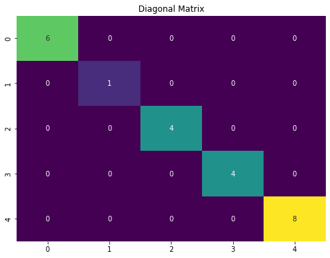

```python
# Plotting the diagonal matrix as a heatmap
plt.figure(figsize=(8, 6))
sns.heatmap(diagonal_matrix, annot=True, cmap='viridis', cbar=False)
plt.title('Diagonal Matrix')
plt.show()
```

#### Interpretation

From the visualization:

- The heatmap represents our diagonal matrix. Notice that all values outside the main diagonal are zeros.
- Only the main diagonal contains non-zero values, which are the unique characteristics of a diagonal matrix.

Diagonal matrices are significant in linear algebra because they simplify many operations. For instance, raising a diagonal matrix to a power is achieved by raising each of its diagonal elements to that power. This property is particularly useful in quantum mechanics when dealing with certain quantum gates.

#### Conclusion

Through this exercise, we've visualized and understood the concept of a diagonal matrix. Diagonal matrices simplify many mathematical operations and are fundamental in various fields, including quantum mechanics.

#### Identity Matrix

An identity matrix is a square matrix that does not change a vector when multiplied. The values of an identity matrix are known. All of the scalar values along the main diagonal (top-left to bottom-right) have the value one, while all other values are zero.

> $a = \begin{bmatrix} 1 & 0 & 0 \\ 0 & 1 & 0\\ 0 & 0 & 1 \end{bmatrix}$

#### Exercise 4 Understanding Identity Matrices using Python

#### Problem Statement

You are a data scientist working for a robotics company. Identity matrices are frequently used in various algorithms, especially when dealing with transformations and rotations. Your task is to generate an identity matrix and visualize its structure.

**Objective:** Generate an identity matrix and visualize its structure. Understand the properties and significance of identity matrices.

#### Step 1: Importing Necessary Libraries

```python
import numpy as np
import matplotlib.pyplot as plt
import seaborn as sns
```

#### Step 2: Generating the Identity Matrix

For this exercise, we'll create a 5x5 identity matrix.

```python
# Generating a 5x5 identity matrix
identity_matrix = np.eye(5)
```

#### Step 3: Visualizing the Identity Matrix

We'll use a heatmap to visualize the structure of the identity matrix.

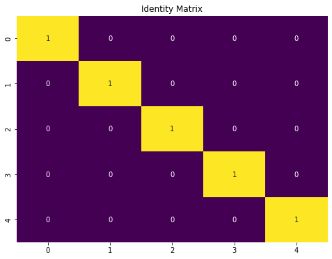

```python
# Plotting the identity matrix as a heatmap
plt.figure(figsize=(8, 6))
sns.heatmap(identity_matrix, annot=True, cmap='viridis', cbar=False)
plt.title('Identity Matrix')
plt.show()
```

#### Interpretation

From the visualization:

- The heatmap represents our identity matrix. Notice that all values outside the main diagonal are zeros.
- Only the main diagonal contains values, and they are all ones, which are the unique characteristics of an identity matrix.

Identity matrices are significant in linear algebra because they act as the "neutral element" in matrix multiplication. When any matrix is multiplied by an identity matrix, the result is the original matrix. This property is analogous to multiplying numbers by one in arithmetic.

#### Conclusion

Through this exercise, we've visualized and understood the concept of an identity matrix. Identity matrices play a crucial role in linear algebra, serving as the multiplicative identity for matrices.

#### Orthogonal Matrix

Two vectors are orthogonal when their dot product equals zero. The length of each vector is 1 then the vectors are called orthonormal because they are both orthogonal and normalized.

> $v.w^t = 0$

#### Exercise 5 Understanding Orthogonal Matrices using Python

#### Problem Statement

You are a data scientist working for a company that specializes in computer graphics. Orthogonal matrices are frequently used in graphics transformations, especially when dealing with rotations that preserve lengths and angles. Your task is to generate an orthogonal matrix, verify its properties, and visualize its structure.

**Objective:** Generate an orthogonal matrix, verify its orthogonality, and visualize its structure. Understand the properties and significance of orthogonal matrices.

#### Step 1: Importing Necessary Libraries

```python
import numpy as np
import matplotlib.pyplot as plt
import seaborn as sns
```

#### Step 2: Generating an Orthogonal Matrix

For simplicity, we'll create a 2x2 orthogonal matrix.

```python
# Generating a 2x2 orthogonal matrix
theta = np.pi / 4  # 45 degree rotation
orthogonal_matrix = np.array([[np.cos(theta), -np.sin(theta)],
                              [np.sin(theta), np.cos(theta)]])
```

#### Step 3: Verifying Orthogonality

An orthogonal matrix, when multiplied by its transpose, should give the identity matrix. Let's verify this property.

```python
# Verifying orthogonality
resultant_matrix = np.dot(orthogonal_matrix, orthogonal_matrix.T)
```

#### Step 4: Visualizing the Orthogonal Matrix and Resultant Matrix

We'll use a heatmap to visualize the structure of both matrices.

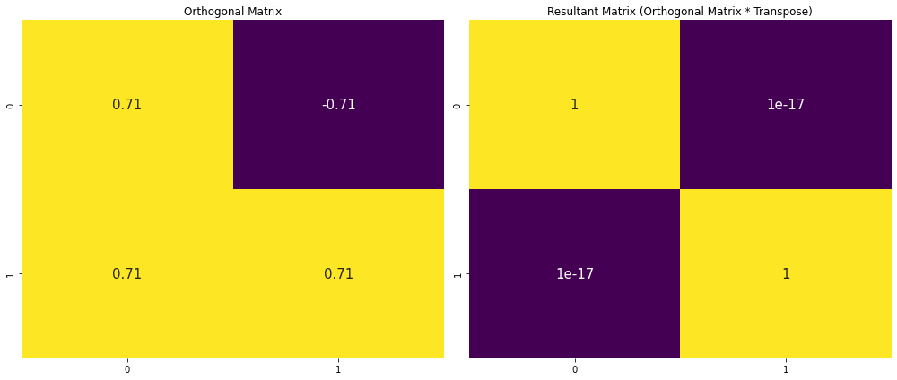

```python
# Plotting the orthogonal matrix and resultant matrix as heatmaps
fig, (ax1, ax2) = plt.subplots(1, 2, figsize=(14, 6))

sns.heatmap(orthogonal_matrix, annot=True, cmap='viridis', cbar=False, ax=ax1, annot_kws={"size": 15})
ax1.set_title('Orthogonal Matrix')

sns.heatmap(resultant_matrix, annot=True, cmap='viridis', cbar=False, ax=ax2, annot_kws={"size": 15})
ax2.set_title('Resultant Matrix (Orthogonal Matrix * Transpose)')

plt.tight_layout()
plt.show()
```

#### Interpretation

From the visualizations:

- The first heatmap represents our orthogonal matrix. It's derived from a rotation matrix, which is inherently orthogonal.
- The second heatmap represents the resultant matrix after multiplying the orthogonal matrix with its transpose. As expected, it's an identity matrix, confirming the orthogonality of our original matrix.

Orthogonal matrices are significant in linear algebra and computer graphics because they represent transformations that preserve lengths and angles. This property is especially useful in rotations and reflections.

#### Conclusion

Through this exercise, we've generated, verified, and visualized an orthogonal matrix. We've also understood the significance of orthogonal matrices in linear transformations, especially in the context of computer graphics.

### Matrix Operations

Matrix operations are used in the description of many machine learning algorithms. Some operations can be used directly to solve key equations, whereas others provide useful shorthand or foundation in the description and the use of more complex matrix operations.

#### Transpose

A defined matrix can be transposed, which creates a new matrix with the number of columns and rows flipped. This is denoted by the superscript $T$ next to the matrix $A^T$.

> $C = A^T$

#### Exercise 6 Understanding the Transpose of a Matrix using Python

#### Problem Statement

You are a data scientist working for a company that specializes in data transformations. One of the fundamental transformations in linear algebra is the transpose of a matrix. Your task is to generate a matrix, compute its transpose, and visualize both matrices to understand the transformation.

**Objective:** Generate a matrix, compute its transpose, and visualize both matrices. Understand the properties and significance of the transpose operation.

#### Step 1: Importing Necessary Libraries

```python
import numpy as np
import matplotlib.pyplot as plt
import seaborn as sns
```

#### Step 2: Generating a Matrix

For this exercise, we'll create a 3x2 matrix.

```python
# Generating a 3x2 matrix
matrix = np.array([[1, 2],
                  [3, 4],
                  [5, 6]])
```

#### Step 3: Computing the Transpose

The transpose of a matrix is obtained by flipping it over its main diagonal. Let's compute the transpose of our matrix.

```python
# Computing the transpose of the matrix
transpose_matrix = matrix.T
```

#### Step 4: Visualizing the Matrix and its Transpose

We'll use a heatmap to visualize the structure of both matrices.

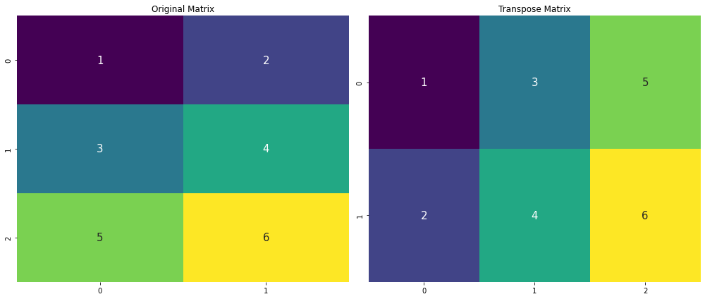

```python
# Plotting the matrix and its transpose as heatmaps
fig, (ax1, ax2) = plt.subplots(1, 2, figsize=(14, 6))

sns.heatmap(matrix, annot=True, cmap='viridis', cbar=False, ax=ax1, annot_kws={"size": 15})
ax1.set_title('Original Matrix')

sns.heatmap(transpose_matrix, annot=True, cmap='viridis', cbar=False, ax=ax2, annot_kws={"size": 15})
ax2.set_title('Transpose Matrix')

plt.tight_layout()
plt.show()
```

#### Interpretation

From the visualizations:

- The first heatmap represents our original matrix.
- The second heatmap represents the transpose of our original matrix. We can observe that the rows of the original matrix have become columns in the transpose matrix and vice versa.

The transpose operation is fundamental in linear algebra and has applications in various domains, including computer graphics, statistics, and machine learning.

#### Conclusion

Through this exercise, we've generated a matrix, computed its transpose, and visualized both matrices. We've also understood the significance of the transpose operation in transforming the rows and columns of a matrix.

#### Exercise 7 Transposing a Matrix using Nested List Comprehension in Python

#### Problem Statement

You are a data scientist working on optimizing matrix operations. One of the tasks you've been given is to transpose a matrix without using any external libraries like NumPy. Your challenge is to use nested list comprehension to achieve this.

**Objective:** Generate a matrix and transpose it using nested list comprehension. Visualize the original and transposed matrices.

#### Step 1: Generating a Matrix

For this exercise, we'll create a 3x2 matrix using nested lists.

```python
# Generating a 3x2 matrix using nested lists
matrix = [[1, 2],
          [3, 4],
          [5, 6]]
```

#### Step 2: Transposing the Matrix using Nested List Comprehension

The transpose of a matrix is obtained by flipping it over its main diagonal. We can achieve this using nested list comprehension.

```python
# Transposing the matrix using nested list comprehension
transpose_matrix = [[ row[i] for row in matrix] for i in range(len(matrix[0]))]
```

#### Step 3: Visualizing the Matrix and its Transpose

We'll use a simple method to print both matrices for visualization.

```python
# Printing the original and transposed matrices
print("Original Matrix:")
for row in matrix:
    print(row)

print("\nTransposed Matrix:")
for row in transpose_matrix:
    print(row)
```

```
Original Matrix:
[1, 2]
[3, 4]
[5, 6]

Transposed Matrix:
[1, 3, 5]
[2, 4, 6]
```

#### Interpretation

From the printed matrices:

- The first set of lists represents our original matrix.
- The second set of lists represents the transpose of our original matrix. We can observe that the rows of the original matrix have become columns in the transpose matrix and vice versa.

Using nested list comprehension, we've efficiently transposed the matrix without the need for any external libraries. This method is particularly useful when working with pure Python without additional dependencies.

#### Conclusion

Through this exercise, we've generated a matrix and transposed it using nested list comprehension. We've visualized the original and transposed matrices and understood the significance of the transpose operation in transforming the rows and columns of a matrix.

#### Inverse

Matrix inversion is a process that finds another matrix that when multiplied with the matrix, results in an identity matrix. Given a matrix $A$, find matrix $B$, such that $AB = I^n$ or $BA = I^n$

> $AB = BA = I^n$

#### Exercise 8 Understanding Matrix Inversion in Python

#### Problem Statement

Matrix inversion is a fundamental operation in linear algebra that plays a critical role in various applications, including solving systems of linear equations and finding matrix determinants.

In this exercise, you will generate a square matrix, compute its inverse, and verify the properties of matrix inversion.

**Objective:** Generate a square matrix, compute its inverse, and verify the matrix inversion properties.

#### Step 1: Generating a Square Matrix

For this exercise, we'll create a 3x3 matrix using `numpy`.

```python
import numpy as np

# Generating a random 3x3 matrix
matrix = np.random.rand(3, 3)
print("Original Matrix:")
print(matrix)
```

```
Original Matrix:
[[0.4236548  0.64589411 0.43758721]
 [0.891773   0.96366276 0.38344152]
 [0.79172504 0.52889492 0.56804456]]
```

#### Step 2: Computing the Inverse of the Matrix

Using `numpy`, we can easily compute the inverse of our matrix.

```python
# Computing the inverse of the matrix
inverse_matrix = np.linalg.inv(matrix)
print("Inverse Matrix:")
print(inverse_matrix)
```

```
Inverse Matrix:
[[-3.06082719  1.20317119  1.54571156]
 [ 1.80296325  0.93968096 -2.02319753]
 [ 2.58739459 -2.55186537  1.48981331]]
```

#### Step 3: Verifying the Properties of Matrix Inversion

One of the fundamental properties of matrix inversion is that when a matrix is multiplied by its inverse, the result is the identity matrix. Let's verify this property.

```python
# Multiplying the matrix with its inverse
product = np.dot(matrix, inverse_matrix)
print("Product of Matrix and its Inverse:")
print(product)
```

```
Product of Matrix and its Inverse:
[[ 1.00000000e+00  1.28373085e-16  1.27257918e-16]
 [-3.57032188e-17  1.00000000e+00  1.27325322e-16]
 [ 3.00701548e-17 -1.70077434e-16  1.00000000e+00]]
```

#### Interpretation

From the printed product:

- We expect the product of the matrix and its inverse to be close to the identity matrix. Due to numerical precision, there might be very small deviations from the exact identity matrix, but they should be negligible.

The ability to compute and understand the inverse of a matrix is crucial in many areas of science and engineering, especially when solving systems of linear equations.

#### Conclusion

Through this exercise, we've generated a square matrix, computed its inverse, and verified the fundamental properties of matrix inversion. This understanding is foundational in linear algebra and has wide-ranging applications in various fields.

#### Trace

A trace of a square matrix is the sum of the values on the main diagonal of the matrix (top-left to bottom-right).

The trace operator gives the sum of all of the diagonal entries of a matrix.

The operation of calculating a trace on a square matrix is described using the notation $tr(A)$ where A is the square matrix on which the operation is being performed.

The trace is calculated as the sum of the diagonal values; for example, in the case of a 3 × 3 matrix: $tr(A) = a_1,_1+a_2,_2+a_3,_3$

#### Exercise 9 Understanding the Trace of a Matrix in Python

#### Problem Statement

The trace of a matrix is the sum of its diagonal elements. It is an important concept in linear algebra and has applications in various fields, including the study of eigenvalues, determinants, and matrix norms.

In this exercise, you will generate a square matrix and compute its trace.

**Objective:** Generate a square matrix and calculate its trace.

#### Step 1: Generating a Square Matrix

For this exercise, we'll create a 4x4 matrix using `numpy`.

```python
import numpy as np

# Generating a random 4x4 matrix
matrix = np.random.rand(4, 4)
print("Original Matrix:")
print(matrix)
```

```
Original Matrix:
[[0.92559664 0.07103606 0.0871293  0.0202184 ]
 [0.83261985 0.77815675 0.87001215 0.97861834]
 [0.79915856 0.46147936 0.78052918 0.11827443]
 [0.63992102 0.14335329 0.94466892 0.52184832]]
```

#### Step 2: Computing the Trace of the Matrix

Using `numpy`, we can easily compute the trace of our matrix.

```python
# Computing the trace of the matrix
trace_value = np.trace(matrix)
print(f"Trace of the Matrix: {trace_value}")
```

```
Trace of the Matrix: 3.006130887279039
```

#### Step 3: Interpretation

The trace of a matrix is simply the sum of its diagonal elements. It provides insight into various properties of the matrix, such as its eigenvalues. For instance, the trace of a matrix is equal to the sum of its eigenvalues.

#### Visualization

Let's visualize the matrix and highlight its diagonal elements.

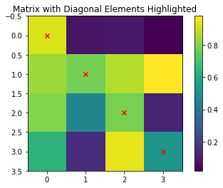

```python
import matplotlib.pyplot as plt

plt.imshow(matrix, cmap='viridis')
plt.colorbar()
# Highlight the diagonal elements
plt.scatter([0, 1, 2, 3], [0, 1, 2, 3], color='red', marker='x')
plt.title("Matrix with Diagonal Elements Highlighted")
plt.show()
```

#### Conclusion

Through this exercise, we've generated a square matrix, computed its trace, and visualized the diagonal elements contributing to the trace. Understanding the trace of a matrix is foundational in linear algebra and offers insights into various matrix properties.

#### Determinant

The determinant of a square matrix is a scalar representation of the volume of the matrix.

It is denoted by the $det(A)$ notation or $|A|$, where A is the matrix on which we are calculating the determinant.

> $det(A)$

#### Exercise 10 Understanding the Determinant of a Matrix in Python

#### Problem Statement

The determinant of a matrix is a scalar value that can be computed from its elements and has a wide range of applications in linear algebra, including determining the invertibility of a matrix and solving systems of linear equations.

In this exercise, you will generate a square matrix and compute its determinant.

**Objective:** Generate a square matrix and calculate its determinant.

#### Step 1: Generating a Square Matrix

For this exercise, we'll create a 3x3 matrix using `numpy`.

```python
import numpy as np

# Generating a random 3x3 matrix
matrix = np.random.rand(3, 3)
print("Original Matrix:")
print(matrix)
```

```
Original Matrix:
[[0.41466194 0.26455561 0.77423369]
 [0.45615033 0.56843395 0.0187898 ]
 [0.6176355  0.61209572 0.616934  ]]
```

#### Step 2: Computing the Determinant of the Matrix

Using `numpy`, we can easily compute the determinant of our matrix.

```python
# Computing the determinant of the matrix
determinant_value = np.linalg.det(matrix)
print(f"Determinant of the Matrix: {determinant_value}")
```

```
Determinant of the Matrix: 0.013617708289304671
```

#### Interpretation

The determinant provides significant information about the matrix. For instance:

- If the determinant is zero, the matrix is singular (non-invertible).
- If the determinant is not zero, the matrix is invertible.
- The absolute value of the determinant gives the scaling factor by which area or volume is transformed by the matrix.

#### Visualization

Let's visualize the matrix using a heatmap.

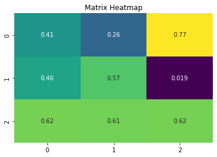

```python
import seaborn as sns
import matplotlib.pyplot as plt
import numpy as np

# Visualizing the matrix using a heatmap
sns.heatmap(matrix, cmap='viridis', annot=True, cbar=False)
plt.title("Matrix Heatmap")
plt.show()
```

#### Conclusion

Through this exercise, we've generated a square matrix, computed its determinant, and visualized the matrix using a heatmap. Understanding the determinant of a matrix is crucial in linear algebra, as it provides insights into the properties and behavior of the matrix.

#### Rank

The rank of a matrix is the estimate of the number of linearly independent rows or columns in a matrix. The rank of a matrix M is often denoted as the function $rank().$

#### Exercise 11 Understanding the Rank of a Matrix in Python

#### Problem Statement

The rank of a matrix is defined as the maximum number of linearly independent column vectors (or row vectors) in the matrix. It provides insights into the matrix's properties and is used in various applications in linear algebra, such as determining the solvability of a system of linear equations.

In this exercise, you will generate a matrix and compute its rank.

**Objective:** Generate a matrix and determine its rank.

#### Step 1: Generating a Matrix

For this exercise, we'll create a 4x4 matrix using `numpy`.

```python
import numpy as np

# Generating a random 4x4 matrix
matrix = np.random.rand(4, 4)
print("Original Matrix:")
print(matrix)
```

```
Original Matrix:
[[0.94374808 0.6818203  0.3595079  0.43703195]
 [0.6976312  0.06022547 0.66676672 0.67063787]
 [0.21038256 0.1289263  0.31542835 0.36371077]
 [0.57019677 0.43860151 0.98837384 0.10204481]]
```

#### Step 2: Computing the Rank of the Matrix

Using `numpy`, we can easily compute the rank of our matrix.

```python
# Computing the rank of the matrix
rank_value = np.linalg.matrix_rank(matrix)
print(f"Rank of the Matrix: {rank_value}")
```

```
Rank of the Matrix: 4
```

#### Interpretation

The rank of a matrix gives us the number of linearly independent rows or columns in the matrix. For instance:

- If the rank of a matrix is equal to the minimum of its number of rows and columns, then the matrix has full rank.
- If the rank is less than the minimum of its number of rows and columns, then the matrix is rank deficient.

#### Visualization

Let's visualize the matrix using a heatmap to get a better understanding of its values.

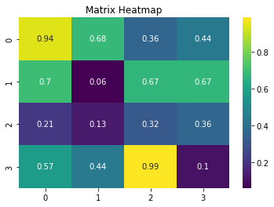

```python
import seaborn as sns
import matplotlib.pyplot as plt

# Assuming 'matrix' is a 2D numpy array or similar data structure
sns.heatmap(matrix, cmap='viridis', annot=True)
plt.title("Matrix Heatmap")
plt.show()
```

#### Conclusion

Through this exercise, we've generated a matrix, computed its rank, and visualized the matrix using a heatmap. Understanding the rank of a matrix is essential in linear algebra, as it provides insights into the linear independence of the matrix's rows and columns.

#### Understanding Eigenvectors and Eigenvalues with Python

> **Eigenvalues :** are scalars $(numbers)$ associated with a square matrix. Given a square matrix $A$, an eigenvalue $(λ) $of $A$ is a scalar that satisfies the following equation:

> $A * v = λ * v$

> Where:
> 1. $A$ is the square matrix under consideration.
> 2. $v$ is a non-zero vector called the eigenvector associated with the eigenvalue $λ.$

> **Eigenvectors:** Eigenvectors are non-zero vectors that correspond to eigenvalues. For each eigenvalue $(λ)$ of a square matrix $A$, there exists an associated eigenvector $v$ such that when the matrix $A$ is multiplied by this eigenvector, the result is a scaled version of the eigenvector:

> $A * v = λ * v$

#### Exercise 12 Understanding Eigenvectors and Eigenvalues in Python

#### Problem Statement

Eigenvectors and eigenvalues are fundamental concepts in linear algebra, especially in the fields of machine learning, data science, and engineering. The eigenvector of a matrix represents a direction, and the corresponding eigenvalue represents the scaling factor in that direction. In other words, when a matrix is multiplied by one of its eigenvectors, the output is a scaled version of the same eigenvector, with the scaling factor being the eigenvalue.

In this exercise, you will generate a matrix, compute its eigenvectors and eigenvalues, and visualize the results.

**Objective:** Generate a matrix and determine its eigenvectors and eigenvalues.

#### Step 1: Generating a Matrix

For this exercise, we'll create a 3x3 matrix using `numpy`.

```python
import numpy as np

# Generating a random 3x3 matrix
matrix = np.random.rand(3, 3)
print("Original Matrix:")
print(matrix)
```

```
Original Matrix:
[[0.20887676 0.16130952 0.65310833]
 [0.2532916  0.46631077 0.24442559]
 [0.15896958 0.11037514 0.65632959]]
```

#### Step 2: Computing the Eigenvectors and Eigenvalues

Using `numpy`, we can easily compute the eigenvectors and eigenvalues of our matrix.

```python
# Computing the eigenvectors and eigenvalues
eigenvalues, eigenvectors = np.linalg.eig(matrix)
print("Eigenvectors:")
print(eigenvectors)
print("\nEigenvalues:")
print(eigenvalues)
```

```
Eigenvectors:
[[-0.60266932 -0.8919926   0.15233799]
 [-0.58605869  0.4266539  -0.95093036]
 [-0.54159478  0.14938422  0.2693039 ]]

Eigenvalues:
[0.95266258 0.02234223 0.3565123 ]
```

#### Interpretation

- **Eigenvectors:** These are the directions in which a transformation acts by merely stretching/compressing the vector, and no change in the direction occurs.
- **Eigenvalues:** These represent the factor by which the eigenvector is stretched or compressed during the transformation.

#### Visualization

Let's visualize the matrix and its eigenvectors.

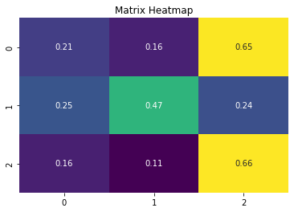

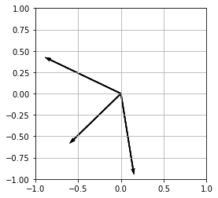

```python
import seaborn as sns
import matplotlib.pyplot as plt

# Assuming 'matrix' is a 2D numpy array or similar data structure
sns.heatmap(matrix, cmap='viridis', annot=True, cbar=False)
plt.title("Matrix Heatmap")
plt.show()

# Visualizing the real part of the eigenvectors
fig, ax = plt.subplots()

# Origin for the eigenvectors
origin = [0, 0, 0]

# Plotting the real part of the eigenvectors
for i in range(3):
    ax.quiver(origin, origin, np.real(eigenvectors[0, i]), np.real(eigenvectors[1, i]), angles='xy', scale_units='xy', scale=1)

ax.set_xlim([-1, 1])
ax.set_ylim([-1, 1])
ax.set_aspect('equal')
plt.grid()
plt.show()
```

This code will plot the real parts of all three components of each eigenvector in a 3D space. Remember that if the eigenvectors have significant imaginary parts, this visualization will not capture that information.

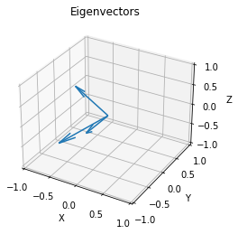

```python
from mpl_toolkits.mplot3d import Axes3D

# Visualizing the real part of the eigenvectors in a 3D plot
fig = plt.figure()
ax = fig.add_subplot(111, projection='3d')

# Origin for the eigenvectors
origin = np.array([0, 0, 0])

# Plotting the real part of the eigenvectors
for i in range(len(eigenvectors)):
    ax.quiver(*origin, np.real(eigenvectors[0, i]), np.real(eigenvectors[1, i]), np.real(eigenvectors[2, i]))

ax.set_xlim([-1, 1])
ax.set_ylim([-1, 1])
ax.set_zlim([-1, 1])
ax.set_xlabel('X')
ax.set_ylabel('Y')
ax.set_zlabel('Z')
ax.set_title("Eigenvectors")
plt.show()
```

#### Conclusion

Through this exercise, we've generated a matrix, computed its eigenvectors and eigenvalues, and visualized the results. Understanding eigenvectors and eigenvalues is crucial in various applications, including principal component analysis (PCA), differential equations, and more.

#### Exercise 13 Compound Interest Comparison Using Matrix Operations

#### Problem Statement

Imagine you have two savings accounts. The first account offers an annual interest rate of 5%, while the second offers an annual interest rate of 3%. Both accounts compound interest annually.

Given an initial investment of $10,000 in each account, how will the accounts grow over a period of 10 years when represented as a matrix? Which account will yield a higher return after 10 years?

#### Objectives:

- Represent the growth of both accounts over 10 years using matrices.
- Calculate the amount in each account for each year over a 10-year period using matrix operations.
- Visualize the growth of each account over time.
- Determine which account yields a higher return after 10 years.

#### Step 1: Define the Interest Rates

We start by defining the interest rates for both accounts. The first account has an interest rate of 5% (`r1 = 0.05`), and the second account has an interest rate of 3% (`r2 = 0.03`).

```python
# Define the interest rates
r1 = 0.05
r2 = 0.03
```

#### Step 2: Create the Growth Matrix

Next, we create a matrix to represent the growth of both accounts over 10 years. Each row of the matrix represents a year, and each column represents an account. The values in the matrix represent the growth factor for each year and account.

```python
# Create the growth matrix
growth_matrix = np.array([[1 + r1, 1 + r2]])
for i in range(1, 10):
    growth_matrix = np.vstack([growth_matrix, [growth_matrix[i-1, 0]*(1+r1), growth_matrix[i-1, 1]*(1+r2)]])
```

#### Step 3: Calculate the Amounts

Using the growth matrix, we can calculate the amount in each account for each year. We start with an initial investment of $10,000 in each account and multiply it by the growth factor for each year to get the amount for that year.

```python
initial_investment = np.array([[10000, 10000]])

# Calculate the amounts for both accounts over 10 years
amounts = initial_investment * growth_matrix
```

#### Step 4: Visualize the Growth

To better understand the growth of the investments, we can plot the amounts in both accounts over the 10-year period. This will allow us to visually compare the growth of the two accounts.

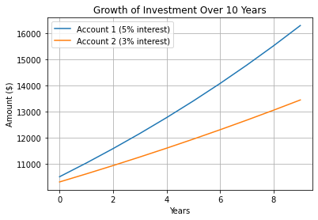

```python
# Visualize the growth
plt.plot(amounts[:, 0], label="Account 1 (5% interest)")
plt.plot(amounts[:, 1], label="Account 2 (3% interest)")
plt.xlabel("Years")
plt.ylabel("Amount ($)")
plt.title("Growth of Investment Over 10 Years")
plt.legend()
plt.grid(True)
plt.show()
```

#### Interpretation

From the plot, we can observe that the account with a 5% interest rate grows faster than the account with a 3% interest rate. By the end of the 10th year, the difference in the amounts in the two accounts becomes quite significant. This demonstrates the power of compound interest and how a small difference in interest rates can lead to a substantial difference in returns over time.

This exercise demonstrates how matrix operations can be used to represent and calculate the growth of investments in multiple accounts over time. It provides a visual representation of the power of compound interest and the impact of different interest rates on the growth of an investment.

#### Matrix Decomposition

Many complex matrix operations cannot be solved efficiently or with stability using the limited precision of computers.

Matrix decompositions are methods that reduce a matrix into constituent parts that make it easier to calculate more complex matrix operations.

##### LU Decomposition

> The $LU$ decomposition is for square matrices and decomposes a matrix into L and U components.

> $A = L.U$

> Where $A$ is the square matrix that we wish to decompose, $L$ is the lower triangle matrix and $U$ is the upper triangle matrix.

> The LU decomposition is found using an iterative numerical process and can fail for those matrices that cannot be decomposed or decomposed easily. A variation of this decomposition that is numerically more stable to solve in practice is called the LUP decomposition, or the LU decomposition with partial pivoting.

> $A = L.U.P$

> The $LU$ decomposition is calculated, then the original matrix is reconstructed from the components.

#### Exercise 14 LU Decomposition

#### Problem Statement

LU Decomposition, also known as LU factorization, refers to the factorization of a matrix into three matrices - a lower triangular matrix (L), an upper triangular matrix (U), and a permutation matrix (P). It's a common operation in numerical methods and plays a crucial role in solving systems of linear equations.

Given a square matrix, your task is to decompose it into L, U, and P matrices using Python.

For this exercise, consider the following matrix `A`:

$A = \begin{bmatrix} 6 & 2 & 1 \\ 2 & 3 & 1 \\ 1 & -1 & 2 \\ \end{bmatrix}$

Let's perform the LU Decomposition of this matrix.

#### Step 1: Import Necessary Libraries

Before we start, we need to import the necessary libraries. We'll use NumPy for matrix operations and SciPy's `lu` function for LU decomposition.

```python
import numpy as np
from scipy.linalg import lu
```

#### Step 2: Define the Matrix

Next, we define the matrix `A` that we want to decompose.

```python
# Define the matrix A
A = np.array([[6, 2, 1],
              [2, 3, 1],
              [1, -1, 2]])
```

#### Step 3: Perform LU Decomposition

Using the `lu` function from SciPy, we can decompose the matrix `A` into `P`, `L`, and `U` matrices.

```python
# Perform LU Decomposition
P, L, U = lu(A)
```

#### Step 4: Display the Decomposed Matrices

Now, let's display the matrices `P`, `L`, and `U` to see the result of the decomposition.

```python
print("P matrix:")
print(P)
print("\nL matrix:")
print(L)
print("\nU matrix:")
print(U)
```

```
P matrix:
[[1. 0. 0.]
 [0. 1. 0.]
 [0. 0. 1.]]

L matrix:
[[ 1.          0.          0.        ]
 [ 0.33333333  1.          0.        ]
 [ 0.16666667 -0.57142857  1.        ]]

U matrix:
[[6.         2.         1.        ]
 [0.         2.33333333 0.66666667]
 [0.         0.         2.21428571]]
```

#### Interpretation

The matrix `A` has been decomposed into three matrices:

- `P`: A permutation matrix that represents the reordering of the rows.
- `L`: A lower triangular matrix with ones on the diagonal.
- `U`: An upper triangular matrix.

The LU Decomposition ensures that:

> $A = P \times L \times U$

This decomposition is particularly useful for solving systems of linear equations, as it can simplify the process significantly.

#### Visualization

To further understand the decomposition, let's visualize matrices `A`, `L`, `U`, and the product of `L` and `U`.

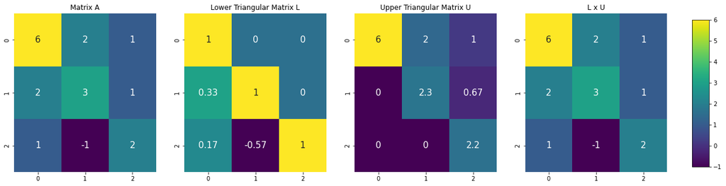

```python
import seaborn as sns
import matplotlib.pyplot as plt
import numpy as np

# Assuming 'A', 'L', 'U' are 2D numpy arrays representing matrices
fig, axs = plt.subplots(1, 4, figsize=(20, 5))

sns.heatmap(A, ax=axs[0], cmap="viridis", annot=True, cbar=False, annot_kws={"size": 15})
axs[0].set_title("Matrix A")

sns.heatmap(L, ax=axs[1], cmap="viridis", annot=True, cbar=False, annot_kws={"size": 15})
axs[1].set_title("Lower Triangular Matrix L")

sns.heatmap(U, ax=axs[2], cmap="viridis", annot=True, cbar=False, annot_kws={"size": 15})
axs[2].set_title("Upper Triangular Matrix U")

sns.heatmap(np.dot(L, U), ax=axs[3], cmap="viridis", annot=True, cbar=False, annot_kws={"size": 15})
axs[3].set_title("L x U")

# Create a colorbar for the entire figure
cbar_ax = fig.add_axes([0.93, 0.15, 0.02, 0.7])  # x, y, width, height
fig.colorbar(axs[3].collections[0], cax=cbar_ax)

plt.show()
```

#### Conclusion

From the visualizations, we can observe that the product of matrices `L` and `U` closely resembles the original matrix `A`, demonstrating the accuracy of the LU Decomposition. This decomposition technique is a foundational concept in linear algebra and numerical analysis, providing an efficient way to solve systems of linear equations.

#### QR Decomposition

The QR decomposition is for $n × m$ matrices (not limited to square matrices) and decomposes a matrix into Q and R components.

QR decomposition decomposes a given matrix A into the product of an orthogonal matrix (Q) and an upper triangular matrix (R), i.e., A = QR.

> $A=Q.R$

Where $A$ is the matrix that we wish to decompose, $Q$ a matrix with the size $m × m,$ and $R$ is an upper triangle matrix with the size $m × n.$

#### Exercise 15 QR Decomposition

#### Problem Statement

QR Decomposition, often referred to as QR factorization, is a decomposition of a matrix into an orthogonal matrix (Q) and an upper triangular matrix (R). It's a fundamental technique in linear algebra and has applications in solving linear least squares problems.

Given a matrix, your task is to decompose it into Q and R matrices using Python.

For this exercise, consider the following matrix `M`:

> $M = \begin{bmatrix} 12 & -51 & 4 \\ 6 & 167 & -68 \\ -4 & 24 & -41 \\ \end{bmatrix}$

Let's perform the QR Decomposition of this matrix.

#### Step 1: Import Necessary Libraries

To start, we need to import the necessary libraries. We'll use NumPy for matrix operations and its `qr` function for QR decomposition.

```python
import numpy as np
```

#### Step 2: Define the Matrix

Next, we define the matrix `M` that we want to decompose.

```python
# Define the matrix M
M = np.array([[12, -51, 4],
              [6, 167, -68],
              [-4, 24, -41]])
```

#### Step 3: Perform QR Decomposition

Using the `qr` function from NumPy, we can decompose the matrix `M` into `Q` and `R` matrices.

```python
# Perform QR Decomposition
Q, R = np.linalg.qr(M)
```

#### Step 4: Display the Decomposed Matrices

Now, let's display the matrices `Q` and `R` to see the result of the decomposition.

```python
print("Q matrix:")
print(Q)
print("\nR matrix:")
print(R)
```

```
Q matrix:
[[-0.85714286  0.39428571  0.33142857]
 [-0.42857143 -0.90285714 -0.03428571]
 [ 0.28571429 -0.17142857  0.94285714]]

R matrix:
[[ -14.  -21.   14.]
 [   0. -175.   70.]
 [   0.    0.  -35.]]
```

#### Interpretation

The matrix `M` has been decomposed into two matrices:

- `Q`: An orthogonal matrix, meaning its transpose is also its inverse.
- `R`: An upper triangular matrix.

The QR Decomposition ensures that:

> $M = Q \times R$

This decomposition is particularly useful in various applications, including solving linear least squares problems and eigenvalue problems.

#### Visualization

To further understand the decomposition, let's visualize matrices `M`, `Q`, `R`, and the product of `Q` and `R`.

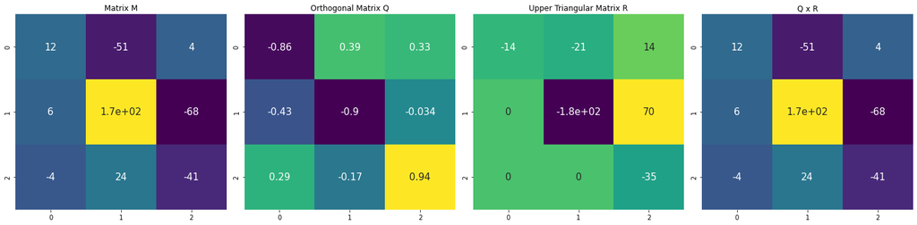

```python
import seaborn as sns
import matplotlib.pyplot as plt
import numpy as np

# Assuming 'M', 'Q', 'R' are 2D numpy arrays representing matrices
fig, ax = plt.subplots(1, 4, figsize=(20, 5))

sns.heatmap(M, ax=ax[0], cmap="viridis", annot=True, cbar=False, annot_kws={"size": 15})
ax[0].set_title("Matrix M")

sns.heatmap(Q, ax=ax[1], cmap="viridis", annot=True, cbar=False, annot_kws={"size": 15})
ax[1].set_title("Orthogonal Matrix Q")

sns.heatmap(R, ax=ax[2], cmap="viridis", annot=True, cbar=False, annot_kws={"size": 15})
ax[2].set_title("Upper Triangular Matrix R")

sns.heatmap(np.dot(Q, R), ax=ax[3], cmap="viridis", annot=True, cbar=False, annot_kws={"size": 15})
ax[3].set_title("Q x R")

# Adjust the layout
plt.tight_layout()

# Show the plot
plt.show()
```

#### Conclusion

From the visualizations, we can observe that the product of matrices `Q` and `R` closely resembles the original matrix `M`, demonstrating the accuracy of the QR Decomposition. This decomposition technique is essential in linear algebra, providing a foundation for various algorithms in numerical analysis.

## Application of Matrix Decomposition

**1. Solving Linear Systems:**

Matrix decomposition methods, such as LU decomposition, are used to solve systems of linear equations efficiently. By decomposing the coefficient matrix, solving for the unknown variables becomes more manageable.

**2. Principal Component Analysis (PCA):**

PCA involves eigenvalue decomposition or singular value decomposition (SVD) to identify the principal components in high-dimensional data. It is a fundamental technique in dimensionality reduction and data visualization.

**3. Matrix Approximations:**

Matrix factorization techniques like SVD, QR decomposition, and NMF are used to approximate large matrices, reducing their dimensionality while preserving essential information. These approximations are used in various data analysis tasks.**

#### Singular Value Decomposition (SVD)

> The Singular-Value Decomposition, or SVD for short, is a matrix decomposition method for reducing a matrix to its constituent parts in order to make certain subsequent matrix calculations simpler.

> $A = U · Σ · V^T$

#### Exercise 16 Singular Value Decomposition (SVD)

#### Problem Statement

Singular Value Decomposition (SVD) is a powerful matrix decomposition method that decomposes a matrix into three other matrices. It has applications in signal processing, statistics, and even machine learning (like in Principal Component Analysis).

Given a matrix, your task is to decompose it using SVD into matrices `U`, `Σ`, and `V*`.

For this exercise, consider the following matrix `A`:

> $A = \begin{bmatrix} 4 & 0 \\ 0 & 3 \\ 2 & 2 \\ \end{bmatrix}$

Let's perform the Singular Value Decomposition of this matrix.

#### Step 1: Import Necessary Libraries

To begin, we need to import the necessary libraries. We'll use NumPy for matrix operations and its `svd` function for the decomposition.

```python
import numpy as np
```

#### Step 2: Define the Matrix

Next, we define the matrix `A` that we want to decompose.

```python
# Define the matrix A
A = np.array([[4, 0],
              [0, 3],
              [2, 2]])
```

#### Step 3: Perform Singular Value Decomposition

Using the `svd` function from NumPy, we can decompose the matrix `A` into `U`, `Σ`, and `V*` matrices.

```python
# Perform Singular Value Decomposition
U, S, Vt = np.linalg.svd(A)
```

#### Step 4: Display the Decomposed Matrices

Now, let's display the matrices `U`, `Σ`, and `V*` to see the result of the decomposition.

```python
print("U matrix:")
print(U)
print("\nΣ matrix:")
print(np.diag(S))
print("\nV* matrix:")
print(Vt)
```

```
U matrix:
[[-0.779875    0.49422059 -0.38411064]
 [-0.26541187 -0.81686073 -0.51214752]
 [-0.56687875 -0.29746352  0.76822128]]

Σ matrix:
[[4.67066086 0.        ]
 [0.         3.3443874 ]]

V* matrix:
[[-0.91063291 -0.41321628]
 [ 0.41321628 -0.91063291]]
```

#### Interpretation

The matrix `A` has been decomposed into three matrices:

- `U`: Represents the left singular vectors of `A`.
- `Σ`: A diagonal matrix containing the singular values of `A`.
- `V*`: Represents the right singular vectors of `A`.

The SVD ensures that:

> $A = U \times Σ \times V*$

This decomposition is particularly useful in various applications, including data compression, noise reduction, and feature extraction in machine learning.

#### Visualization

To further understand the decomposition, let's visualize matrices `A`, `U`, `Σ`, and `V*`, and the product of `U`, `Σ`, and `V*`.

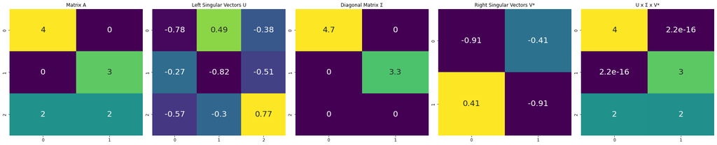

```python
import seaborn as sns
import matplotlib.pyplot as plt
import numpy as np

# Assuming 'A', 'U', 'S', and 'Vt' are defined as per SVD requirements
# Convert the 1D array of singular values to a full diagonal matrix
Sigma = np.zeros((U.shape[1], Vt.shape[0]))
np.fill_diagonal(Sigma, S)

fig, axs = plt.subplots(1, 5, figsize=(25, 5), constrained_layout=True)

sns.heatmap(A, ax=axs[0], cmap="viridis", annot=True, cbar=False, annot_kws={"size": 20})
axs[0].set_title("Matrix A")

sns.heatmap(U, ax=axs[1], cmap="viridis", annot=True, cbar=False, annot_kws={"size": 20})
axs[1].set_title("Left Singular Vectors U")

sns.heatmap(Sigma, ax=axs[2], cmap="viridis", annot=True, cbar=False, annot_kws={"size": 20})
axs[2].set_title("Diagonal Matrix Σ")

sns.heatmap(Vt, ax=axs[3], cmap="viridis", annot=True, cbar=False, annot_kws={"size": 20})
axs[3].set_title("Right Singular Vectors V*")

sns.heatmap(np.dot(U, np.dot(Sigma, Vt)), ax=axs[4], cmap="viridis", annot=True, cbar=False, annot_kws={"size": 20})
axs[4].set_title("U x Σ x V*")

plt.show()
```

#### Conclusion

From the visualizations, we can observe that the product of matrices `U`, `Σ`, and `V*` closely resembles the original matrix `A`, demonstrating the accuracy of the SVD. This decomposition technique is essential in linear algebra and has significant applications in various fields, especially in data science and machine learning.

#### Real Life Use Case of SVD in Machine Learning.

Applying Singular Value Decomposition (SVD) to real-world datasets for dimensionality reduction is a common and powerful technique used in various fields such as image processing, natural language processing (NLP), and recommendation systems. Dimensionality reduction can help reduce the computational complexity of a dataset while preserving its essential characteristics. In this example, we'll demonstrate how to apply SVD for dimensionality reduction using a real-world dataset.

#### Exercise 17 Dimensionality Reduction using Singular Value Decomposition (SVD)

#### Problem Statement

You have been given a dataset containing images of handwritten digits. Each image is represented as a 64-dimensional vector. Your task is to use Singular Value Decomposition (SVD) to reduce the dimensionality of this dataset while preserving its essential characteristics.

#### Dataset

We will use the handwritten digits dataset from the sklearn library. This dataset contains 1,797 samples of handwritten digits, where each sample is an 8x8 image, and thus represented as a 64-dimensional vector.

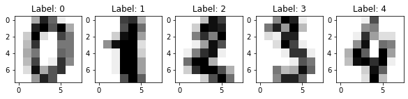

```python
# Step 1: Load the dataset

from sklearn.datasets import load_digits
import matplotlib.pyplot as plt
import warnings

# Settings the warnings to be ignored
warnings.filterwarnings('ignore')

digits = load_digits()
X = digits.data
y = digits.target

# Display the first few images
fig, axes = plt.subplots(1, 5, figsize=(10, 4))
for ax, image, label in zip(axes, X, y):
    ax.imshow(image.reshape(8, 8), cmap=plt.cm.gray_r)
    ax.set_title(f'Label: {label}')
```

The above code loads the handwritten digits dataset and displays the first few images. Each image is represented as a 64-dimensional vector.

```python
# Step 2: Apply SVD and reduce the dimensionality

from sklearn.decomposition import TruncatedSVD

# Reduce dimensions to 2 using SVD
svd = TruncatedSVD(n_components=2)
X_reduced = svd.fit_transform(X)
```

Here, we use the `TruncatedSVD` class from `sklearn` to reduce the dimensionality of our dataset from 64 to 2. This will allow us to easily visualize the data in a 2D space.

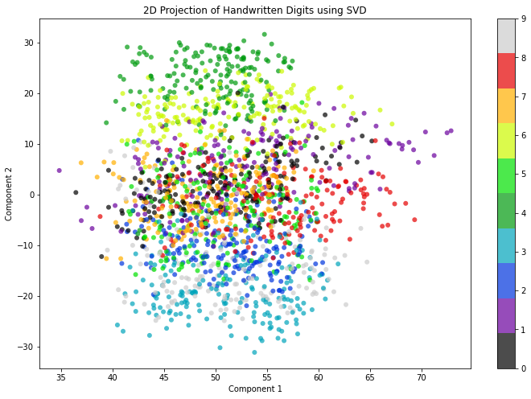

```python
# Step 3: Visualize the original and reduced data

plt.figure(figsize=(12, 8))
plt.scatter(X_reduced[:, 0], X_reduced[:, 1], c=y, edgecolor='none', alpha=0.7, cmap=plt.cm.get_cmap('nipy_spectral', 10))
plt.colorbar()
plt.title('2D Projection of Handwritten Digits using SVD')
plt.xlabel('Component 1')
plt.ylabel('Component 2')
plt.show()
```

The scatter plot visualizes the 2D projection of the handwritten digits dataset after applying SVD. Each point in the plot represents an image, and the colors represent the actual digit labels. This visualization allows us to see how well SVD has preserved the structure and relationships between different digits in the reduced space.

#### Conclusion

From the visualization, we can observe clusters of similar digits grouped together, indicating that SVD has effectively captured the underlying structure of the data in just two dimensions. This technique can be particularly useful in applications where computational efficiency is crucial, as working with reduced dimensions can significantly speed up algorithms without sacrificing much information.

### Case Study : Linear Algebra In Machine Learning

#### Introduction

Linear algebra is a foundational topic in machine learning. From data representation to optimization techniques, the concepts of vectors, matrices, and linear equations play a crucial role. In this case study, we will explore how these concepts are applied in a simple linear regression problem.

#### Problem Statement

You are a data scientist at a real estate company. The company wants to predict the price of houses based on their size (in square feet). You have been provided with a dataset containing the size and price of various houses sold in the past. Your task is to build a linear regression model using the concepts of linear algebra.

#### Dataset

For simplicity, let's consider a small dataset:

| Size (sq.ft) | Price (in $) |
| --- | --- |
| 650 | 77250 |
| 785 | 92850 |
| 1200 | 135000 |
| 720 | 86000 |
| 975 | 110500 |

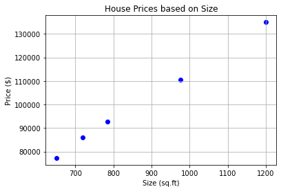

```python
# Import necessary libraries
import numpy as np
import matplotlib.pyplot as plt

# Define the dataset
sizes = np.array([650, 785, 1200, 720, 975])
prices = np.array([77250, 92850, 135000, 86000, 110500])

# Visualize the data
plt.scatter(sizes, prices, color='blue')
plt.xlabel('Size (sq.ft)')
plt.ylabel('Price ($)')
plt.title('House Prices based on Size')
plt.grid(True)
plt.show()
```

The scatter plot visualizes the relationship between house sizes and their respective prices. It seems there's a linear relationship between the two.

#### Vectors and Matrices in Linear Regression

Linear regression can be represented as:

> $y = X \beta + \epsilon$

Where:

- ( y ) is the vector of target values (prices).
- ( X ) is the matrix of input features (sizes).
- $\beta$ is the vector of coefficients.
- $\epsilon$ is the error term.

To find the best-fitting line, we aim to minimize the error term. Using linear algebra, the coefficients $\beta$ can be found as:

> $\beta = (X^T X)^{-1} X^T y$

```python
# Prepare the input matrix X and target vector y
X = np.vstack([np.ones(sizes.shape[0]), sizes]).T
y = prices

# Calculate the coefficients using the normal equation
beta = np.linalg.inv(X.T @ X) @ X.T @ y

print(f"Intercept: {beta[0]:.2f}")
print(f"Slope (Price per sq.ft): {beta[1]:.2f}")
```

```
Intercept: 11206.25
Slope (Price per sq.ft): 102.90
```

The intercept represents the base price of a house regardless of its size, while the slope indicates the price increase per additional square foot.

#### Predicting House Prices

With the coefficients in hand, we can now predict the price of any house given its size.

> $\hat{y} = X \beta$

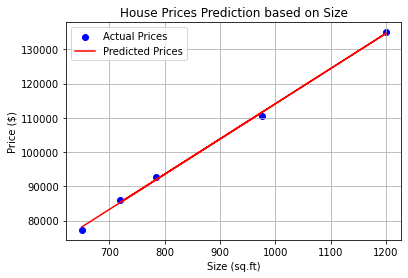

```python
# Predict prices using the linear model
predicted_prices = X @ beta

# Visualize the original data and the best-fitting line
plt.scatter(sizes, prices, color='blue', label='Actual Prices')
plt.plot(sizes, predicted_prices, color='red', label='Predicted Prices')
plt.xlabel('Size (sq.ft)')
plt.ylabel('Price ($)')
plt.title('House Prices Prediction based on Size')
plt.legend()
plt.grid(True)
plt.show()
```

The red line represents the predictions of our linear regression model. As observed, it fits the actual data points quite well, indicating a good model.

#### Conclusion

In this case study, we applied the concepts of vectors, matrices, and linear equations to build a linear regression model. Linear algebra provides the tools and techniques to efficiently compute solutions in machine learning, making it an essential topic for any data scientist or machine learning practitioner.

#### Revised Date: November 6, 2023